# IS 609 Final Project

Cheryl Bowersox, Conor Buckley, David Stern

November 23, 2015

## Chapter 5.3, Project 1

This project asks to construct and perform a Monte Carlo simulation of blackjack.  
These are the requirements outlined in the project:  
- Play 12 games (simulations) where each game lasts two decks.  
- When the two decks are out, the round is completed using two fresh decks.  
- That is then the last round of the game.  
- The results of that game are recorded.  
- Everything is reset for the start of the next game.  
- The dealer cannot see the players cards and vice versa.  
- The player wins 3 dollars with a winning hand.  
- The player loses 2 dollars with a losing hand.  
- No money is exchanged if there is no winner.  
- There is no winner when neither has gone bust and they stand at the same amount.  
- If the dealer goes bust, the player automatically wins.  
- The dealer strategy is to stand at 17 or above.  
- The player strategy is open and can be set as desired.

In order to tackle the above project the game of blackjack was created programmatically, incorporating the betting structure provided. Instead of implementing just one player strategy, a number of versions of the same strategy were implemented. That is, player strategies to stand at 15 up to 20 were simulated.

In addition, to extend this project, simulation sizes of 50, 100, 500 and 1,000 were run and the results were examined. This exercise used the benefits of Monte Carlo simulation in order to arrive at a long-term average return per strategy, which would help identify the most profitable strategy for the player.

*Create a two deck game*

The following are a series of functions to create the game of blackjack from a dealt card, up to a hand, up to a round, and up to a full two-deck game. The results of every game are put in an outcome vector: 1 for dealer win, 2 for player win, 0 for no winner. This outcome vector is then used to calculate the winnings/losses for the player. It is possible to pass a different standing amount to the player. This allows for different strategies to be examined.

First we have the general function to deal a card from a deck. It returns a list containing the card, the remaining deck and the last round flag. The last round occurs when the deck runs out and the last round flag is then set to 1, and the deck is replenished with a new set of two decks to allow the current hand to finish.

```r
deal_card <- function(dc_deck,full2_deck){
  dc_last_round_flag <- 0
  if (length(dc_deck) == 0) {
    dc_last_round_flag <- 1
    dc_deck <- full2_deck
  }
  dc_card <- sample(dc_deck,1,FALSE)
  dc_deck <- dc_deck [! dc_deck %in% dc_card | duplicated(dc_deck)]
  return(list(dc_card,dc_deck,dc_last_round_flag))
}
```

Now we have a function to create a hand for the dealer. It returns a list containing the hand and the remaining deck.

```r
dealer_hand <- function(dh_deck,full2_deck) {
  dh_hand <- 0
  dh_last_round_flag <- 0
  dh_count <- 1
  while (sum(dh_hand) < 17) {
    dh_deal <- deal_card(dh_deck,full2_deck)
    dh_hand[dh_count] <- dh_deal[[1]]
    dh_deck <- dh_deal[[2]]
    if (dh_deal[[3]] == 1) {dh_last_round_flag <- dh_deal[[3]]}
    dh_count <- dh_count+1
    #aces become ones if the hand is greater than 21
    if(sum(dh_hand) > 21) {
      if(11 %in% dh_hand) {
        dh_hand[match(11,dh_hand)] <- 1
      }
    }
  }
  return(list(dh_hand,dh_deck,dh_last_round_flag))
}
```

Here is the function to create a hand for the player. It also returns a list containing the hand and the remaining deck.

```r
player_hand <- function(ph_deck,full2_deck,p_threshold) {
  ph_hand <- 0
  ph_count <- 1
  ph_last_round_flag <- 0
  while (sum(ph_hand) < p_threshold) {
    ph_deal <- deal_card(ph_deck,full2_deck)
    ph_hand[ph_count] <- ph_deal[[1]]
    ph_deck <- ph_deal[[2]]
    if (ph_deal[[3]] == 1) {ph_last_round_flag <- ph_deal[[3]]}
    ph_count <- ph_count+1
    #aces become ones if the hand is greater than 21
    if(sum(ph_hand) > 21) {
      if(11 %in% ph_hand) {
        ph_hand[match(11,ph_hand)] <- 1
      }
    }
  }
  return(list(ph_hand,ph_deck,ph_last_round_flag))
}
```

Here is the function to create a round of play. It returns a list containing the hand of each player and the remaining deck.

```r
round_of_play <- function(rop_deck,full2_deck,p_threshold) {
  #dealer hand
  d_result <- dealer_hand(rop_deck,full2_deck)
  d_hand <- d_result[[1]]
  rop_deck <- d_result[[2]]
  last_round_flag_d <- d_result[[3]]
  #player hand
  p_result <- player_hand(rop_deck,full2_deck,p_threshold)
  p_hand <- p_result[[1]]
  rop_deck <- p_result[[2]]
  last_round_flag_p <- p_result[[3]]

  if (last_round_flag_d == 1 || last_round_flag_p == 1) {
    rop_last_round_flag <- 1
  } else {
    rop_last_round_flag <- 0
  }
  return(list(d_hand,p_hand,rop_deck,rop_last_round_flag))
}
```

This function runs through two decks, creating a hand for the dealer and player in each round. It stores the results in a list of lists, which is returned by the function.

```r
play_two_decks <- function(ptd_deck,full2_deck,p_threshold) {

  round_counter <- 1
  ptd_last_round_flag <- 0
  result_list.names <- c("Dealer_Hand", "Player_Hand")
  result_list <- vector("list", length(result_list.names))
  names(result_list) <- result_list.names

  while (ptd_last_round_flag != 1) {
    round_result <- round_of_play(ptd_deck,full2_deck,p_threshold)
    result_list$Dealer_Hand[round_counter] <- list(round_result[[1]])
    result_list$Player_Hand[round_counter] <- list(round_result[[2]])
    ptd_deck <- round_result[[3]]
    ptd_last_round_flag <- round_result[[4]]
    round_counter <- round_counter+1
  }
  return(result_list)
}
```

This function takes in a list containing all the hands for each player after running through two full decks. It returns a vector of 0’s, 1’s, and 2’s, where 1 denotes a win for the dealer, 2 a win for the player, and 0 a round where there was no winner. If the dealer goes bust, the player automatically wins.

```r
build_outcome_vector <- function(bov_one_set) {

  winner <- numeric(length(bov_one_set$Dealer_Hand))

  for (i in 1:length(bov_one_set$Dealer_Hand)) {
    d_Hand <- sum(bov_one_set$Dealer_Hand[[i]])
    p_Hand <- sum(bov_one_set$Player_Hand[[i]])
    if(d_Hand < 22) {
      if(p_Hand < 22) {
        if(d_Hand > p_Hand) {
          winner[i] <- 1
        } else if (d_Hand < p_Hand) {
            winner[i] <- 2
        } else if (d_Hand == p_Hand) {
            winner[i] <- 0
        }
      } else if(p_Hand >= 22) {
          winner[i] <- 1
      }
    } else if(d_Hand >= 22){
            winner[i] <- 2 #if dealer goes bust player wins automatically
      }
  }
  return(winner)
}
```

This function calculates the player winnings. The betting assumptions are as follows:  
- The player bets 2 dollars on each hand.  
- If player wins, they receive 3 dollars.  
- If player loses, they lose their 2 dollar bet.  
- If it is a tie, then no money is exchanged.  
- If the dealer goes bust, it is a win for the player irrespective of the hand the player holds.

```r
calculate_player_winnings <- function(results) {

  winnings <- numeric(length(results))

  for(i in 1:length(results)) {
    if (results[i] == 0) winnings[i] <- 0
    if (results[i] == 1) winnings[i] <- -2
    if (results[i] == 2) winnings[i] <- 3
  }
  return(winnings)
}
```

Next we have a function to play one full game and calculate the winnings/losses. It uses the standing strategy provided as an argument to the function. It returns the total winnings/loses for the game.

```r
play_two_deck_game <- function(ptdg_deck,p_threshold){
  #create a list of outcomes per round after running through a two full decks
  one_set <- play_two_decks(ptdg_deck,ptdg_deck,p_threshold)
  #build a vector to capture the result of each hand
  #dealer wins (1), player wins (2), no winner (0)
  outcome_vector <- build_outcome_vector(one_set)
  player_winnings <- 0
  #use the outcome vector to calculate the winnings based on
  #the betting strategy provided
  player_winnings <- calculate_player_winnings(outcome_vector)
  return(sum(player_winnings))
}
```

Finally we have a function to run a simulation for a number of two deck games. The function takes the two decks & number of simulations as parameters. Each run uses multiple player standing strategies (from 15 to 20). The strategies are simple - stand at the specified amount. The dealer always stands at 17 (as per the guidance in the project description). The function returns a data frame containing the winnings or losses per strategy per observation.

```r
create_output <- function(co_deck,num_runs) {

  obsCount <- numeric(num_runs)
  vec15 <- numeric(num_runs)
  vec16 <- numeric(num_runs)
  vec17 <- numeric(num_runs)
  vec18 <- numeric(num_runs)
  vec19 <- numeric(num_runs)
  vec20 <- numeric(num_runs)
  for (i in 1:num_runs){
    obsCount[i] <- i
    vec15[i] <- play_two_deck_game(co_deck,15)
    vec16[i] <- play_two_deck_game(co_deck,16)
    vec17[i] <- play_two_deck_game(co_deck,17)
    vec18[i] <- play_two_deck_game(co_deck,18)
    vec19[i] <- play_two_deck_game(co_deck,19)
    vec20[i] <- play_two_deck_game(co_deck,20)
  }
  output <- data.frame("Obs_Count"= obsCount, "Stand_At_15"=vec15,
                     "Stand_At_16"=vec16,"Stand_At_17"=vec17,
                     "Stand_At_18"=vec18,"Stand_At_19"=vec19,
                     "Stand_At_20"=vec20)
  return(output)
}
```

*Run 12 Simulations*

Here we will create a set of two decks and simulate 12 two-deck games. We will run this same simulation for the different strategies implemented in the create_output function above.

Define and create a vector to represent the two decks.

```r
two_deck <- c(2,2,2,2,3,3,3,3,4,4,4,4,5,5,5,5,6,6,6,6,7,7,7,7,8,8,8,8,
              9,9,9,9,10,10,10,10,10,10,10,10,10,10,10,10,10,10,10,10,
              11,11,11,11,2,2,2,2,3,3,3,3,4,4,4,4,5,5,5,5,6,6,6,6,
              7,7,7,7,8,8,8,8,9,9,9,9,10,10,10,10,10,10,10,10,10,10,10,
              10,10,10,10,10,11,11,11,11)
```

Play 12 games for each strategy and print out the results.

```r
#create a simulation for 12 two deck games as per instructed in the question
n12_output <- create_output(two_deck,12)
#put the average winnings/loses in a vector
n12_output_avg <- c("Stand_At_15"=mean(n12_output$Stand_At_15),
                    "Stand_At_16"=mean(n12_output$Stand_At_16),
                    "Stand_At_17"=mean(n12_output$Stand_At_17),
                    "Stand_At_18"=mean(n12_output$Stand_At_18),
                    "Stand_At_19"=mean(n12_output$Stand_At_19),
                    "Stand_At_20"=mean(n12_output$Stand_At_20))
kk <- kable(n12_output,
            caption = "List of Winnings/Loses per Strategy per Observation (dollars)",
            padding = 0)

#print the results to the screen
kk
```

List of Winnings/Loses per Strategy per Observation (dollars)

| Obs_Count | Stand_At_15 | Stand_At_16 | Stand_At_17 | Stand_At_18 | Stand_At_19 | Stand_At_20 |
| --- | --- | --- | --- | --- | --- | --- |
| 1 | 10 | 14 | 8 | 18 | 8 | -9 |
| 2 | 5 | 30 | -11 | 16 | 8 | 19 |
| 3 | 9 | 12 | 7 | 13 | 21 | 13 |
| 4 | 22 | 5 | 15 | 6 | 6 | 13 |
| 5 | 2 | 12 | 24 | 25 | 26 | 6 |
| 6 | 16 | -14 | 21 | 17 | 16 | 3 |
| 7 | 29 | 20 | 21 | 13 | 16 | 18 |
| 8 | 11 | 14 | 21 | 15 | 9 | 8 |
| 9 | -3 | 33 | 14 | 27 | 14 | -2 |
| 10 | 5 | 4 | 17 | 14 | 1 | 13 |
| 11 | 14 | -6 | 26 | 23 | 6 | -4 |
| 12 | 11 | 5 | -10 | 9 | 14 | 10 |

```r
#print the average winnings per strategy to the screen
kable(round(n12_output_avg,2),
      caption = "Average Winnings/Loses per Strategy (dollars)")
```

Average Winnings/Loses per Strategy (dollars)

| Stand_At_15 | 10.92 |
| --- | --- |
| Stand_At_16 | 10.75 |
| Stand_At_17 | 12.75 |
| Stand_At_18 | 16.33 |
| Stand_At_19 | 12.08 |
| Stand_At_20 | 7.33 |

```r
#prepare the data firstly
#add the averages to the bottom of the results
n12_output_full <- rbind(n12_output, c(Obs_Count=0,c(n12_output_avg)))
#convert the data to a long format
n12_output_full <- melt(n12_output_full,
                     id.vars="Obs_Count",
                     value.name="value",
                     variable.name="Strategy")
#add a variable to denote the average vs the standard observations
var <- n12_output_full$Obs_Count
var <- replace(var, var!=0, "obs")
var <- replace(var, var==0, "avg")
n12_output_full$Line_Colour <- var

#create the plot and print it to the screen
gg12 <- ggplot(data=n12_output_full,
       aes(x=Strategy, y=value, group=Obs_Count, colour=Obs_Count))
gg12 <- gg12 + geom_line(aes(colour=Line_Colour))
gg12 <- gg12 + xlab("Strategy")
gg12 <- gg12 + ylab("Winnings (dollars)")
gg12 <- gg12 + ggtitle("Winnings by Strategy per Observation with Average - 12 Simulated Games")
```

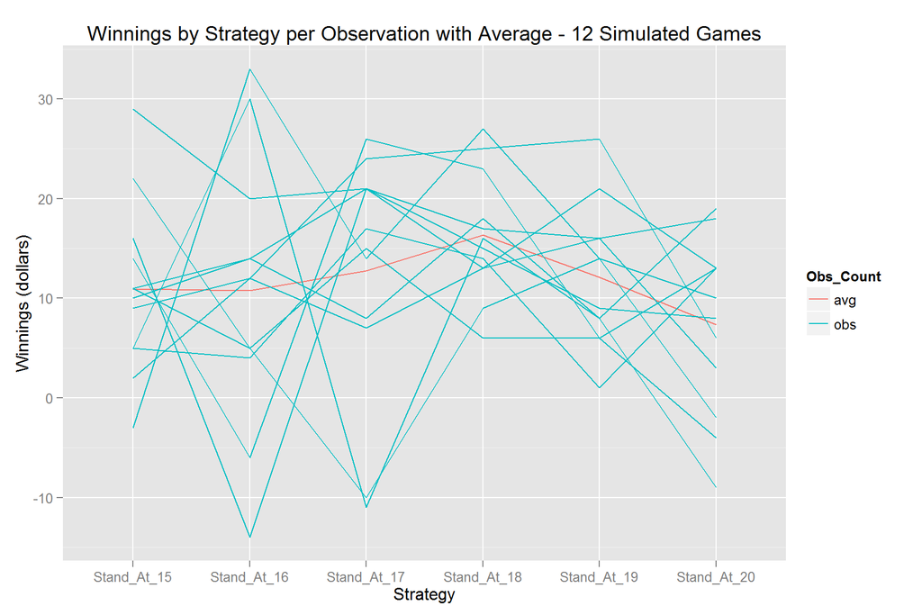

```r
#print out the plot
gg12
```

*Additional work to extend the project*

As can be seen from the graph above there is quite a variation across the same strategies between the observations. It is therefore not especially clear which strategy is best. In order to examine this further it was felt that running the games and strategies with larger simulation sizes would be a useful exercise.

Simulations for 50, 100, 500 & 1000 runs were made in order to establish the winnings per strategy.

```r
#run 50 simulations and store the results
n50_output <- create_output(two_deck,50)
#put the average winnings/loses in a vector
n50_output_avg <- c("Stand_At_15"=mean(n50_output$Stand_At_15),
                      "Stand_At_16"=mean(n50_output$Stand_At_16),
                      "Stand_At_17"=mean(n50_output$Stand_At_17),
                      "Stand_At_18"=mean(n50_output$Stand_At_18),
                      "Stand_At_19"=mean(n50_output$Stand_At_19),
                      "Stand_At_20"=mean(n50_output$Stand_At_20))

#run 100 simulations and store the results
n100_output <- create_output(two_deck,100)
#put the average winnings/loses in a vector
n100_output_avg <- c("Stand_At_15"=mean(n100_output$Stand_At_15),
                      "Stand_At_16"=mean(n100_output$Stand_At_16),
                      "Stand_At_17"=mean(n100_output$Stand_At_17),
                      "Stand_At_18"=mean(n100_output$Stand_At_18),
                      "Stand_At_19"=mean(n100_output$Stand_At_19),
                      "Stand_At_20"=mean(n100_output$Stand_At_20))

#run 500 simulations and store the results
n500_output <- create_output(two_deck,500)
#put the average winnings/loses in a vector
n500_output_avg <- c("Stand_At_15"=mean(n500_output$Stand_At_15),
                      "Stand_At_16"=mean(n500_output$Stand_At_16),
                      "Stand_At_17"=mean(n500_output$Stand_At_17),
                      "Stand_At_18"=mean(n500_output$Stand_At_18),
                      "Stand_At_19"=mean(n500_output$Stand_At_19),
                      "Stand_At_20"=mean(n500_output$Stand_At_20))

#run 1000 simulations and store the results
n1000_output <- create_output(two_deck,1000)
#put the average winnings/loses in a vector
n1000_output_avg <- c("Stand_At_15"=mean(n1000_output$Stand_At_15),
                      "Stand_At_16"=mean(n1000_output$Stand_At_16),
                      "Stand_At_17"=mean(n1000_output$Stand_At_17),
                      "Stand_At_18"=mean(n1000_output$Stand_At_18),
                      "Stand_At_19"=mean(n1000_output$Stand_At_19),
                      "Stand_At_20"=mean(n1000_output$Stand_At_20))
```

Plot the winnings per strategy per number of simulation runs.

```r
#put the data in a data frame
plot_df <- rbind(n50_output_avg,
            n100_output_avg,
            n500_output_avg,
            n1000_output_avg)
#remove the row names
row.names(plot_df) <- NULL
#add a column to record the simulation size
plot_df <- cbind(Simulation_Size=c(50,100,500,1000),plot_df)
#convert the matrix to a data frame
plot_df <- data.frame(plot_df)
#convert the data to long for the plot
plot_df <- melt(plot_df, id.vars="Simulation_Size",
                value.name="value",
                variable.name="Strategy")

#create the plot and print to the screen
gg <- ggplot(data=plot_df,
        aes(x=Strategy, y=value, group=Simulation_Size, colour=Simulation_Size))
gg <- gg + geom_line() + geom_point()
gg <- gg + xlab("Strategy")
gg <- gg + ylab("Winnings (dollars)")
gg <- gg + ggtitle("Winnings by Strategy per Simulation Size")
```

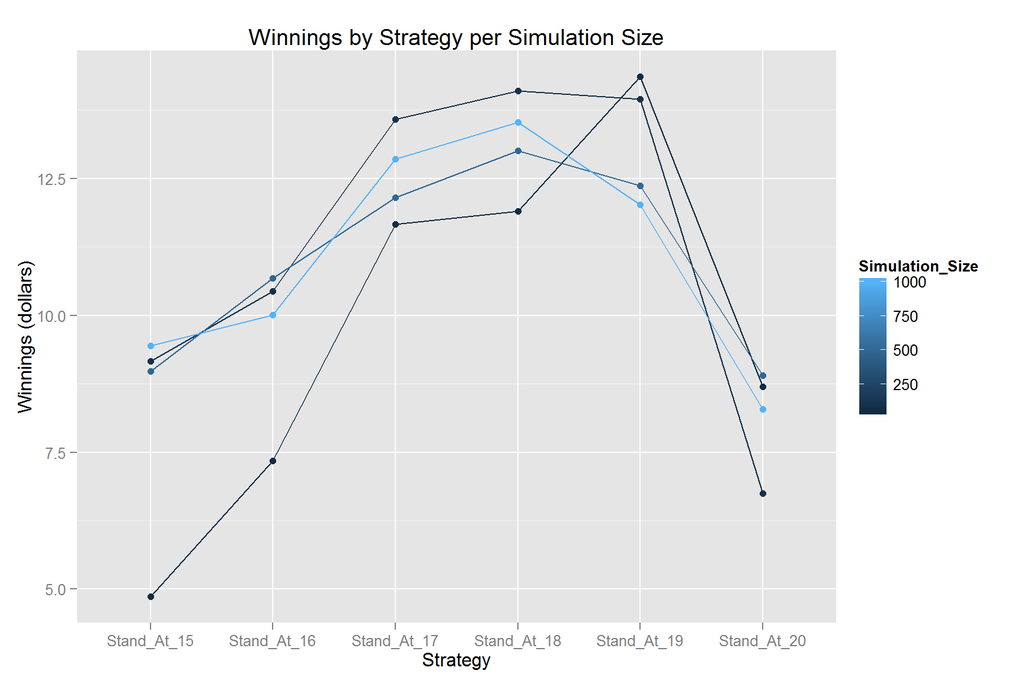

```r
#print out the plot
gg
```

## As expected, the more simulations that are run the more the results converge on certain outcomes. At 1,000 simulations a pattern emerges, which suggests that standing at 18 is better than standing at 17, which is better than standing at 16, which in turn is better than standing at 15. However, standing at 18 is the peak, as standing at 19 results in less winnings, with a strategy of standing at 20 resulting in even lower winnings. Therefore, it is clear that standing at 18, when the dealer stands at 17, is the most profitable strategy for the player.

## Chapter 7.5, Project 2

This project introduces a farming scenario, where the farmer has to decide how much of what to plant, and asks us to use the given information to decide what would be the best ratio. To do this we can use linear programming to solve this as an optimization problem with constraints, analyze the resulting system graphically, and then test the sensitivity of the system by flexing some of those given constraints.

**Scenario**

A farmer has 30 acres on which to grow tomatoes and corn. Each 100 bushels of tomatoes require 1000 gallons of water and 5 acres of land. Each 10 bushels of corn require 6000 gallons of water and 2.5 acres of land. Labor costs are $1 per bushel for both corn and tomatoes. The farm has available 30,000 gallons of water and $750 in capital. He knows he cannot sell more than 500 bushels of tomatoes and 475 bushels of corn. He estimates a profit of $2 on each bushel of tomatoes and $3 on each bushel of corn.

*Part A: How many bushels should he raise to maximize profits?*

$n_{t}$ = number of bushels of tomatoes (in hundreds)  
$n_{c}$ = number of bushels of corn (in hundreds)  
$w$ = number of gallons of water (in thousands)  
$p$ = profit (in dollars)  
$a$ = land (in acres)

Constraints: $30,000$ gallons of water available, $w \leq 30$

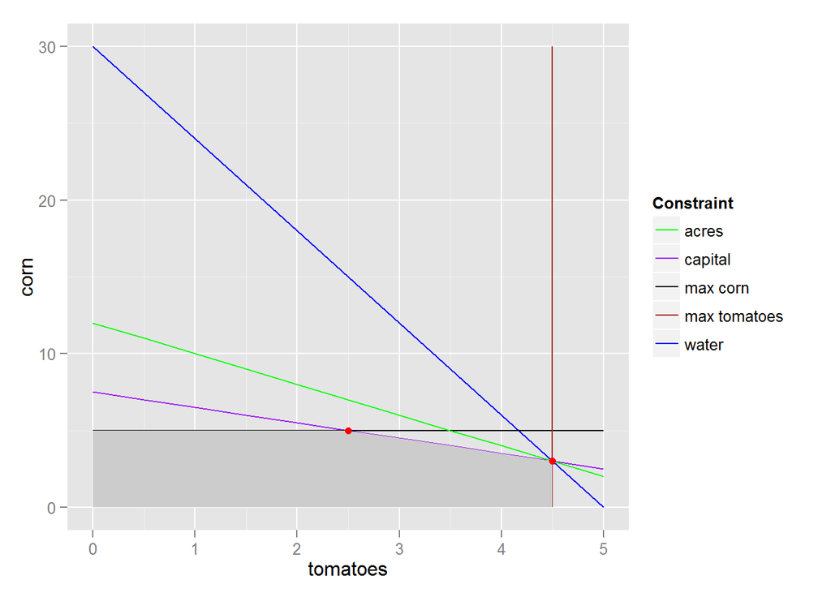

```r
#suppressWarnings(suppressMessages(library(ggplot2)))

f1 <- function(x) 30-6*x #water constraint
f2 <- function(x) 7.5 - x  #capital constraint
f3 <- function(x) 5 #max tomatoes
f4 <- function(x) 12-2*x  #acres
x1 = seq(0,5, by = .5)
x0 = rep(4.5,length(x1))
df = data.frame(x1,x0, water=f1(x1), capital=f2(x1), max_tomato= f3(x1), acres = f4(x1))
df <-  transform(df, z =pmin(water,capital,5,acres), z2 = pmin(x1,4.5))
ggplot(df, aes(x = x1)) +
  geom_line(aes(y = water, colour = 'water'))+
  geom_line(aes(y = capital, colour = 'capital'))+
  geom_line(aes(y = max_tomato, colour = 'max corn')) +
  geom_line(aes(y = acres, colour = 'acres')) +
  geom_line(aes(y = water, x = x0, colour = 'max tomatoes'))+
  geom_ribbon(aes(ymin=0, ymax = z, x= z2), fill = 'gray80') +
  geom_point(aes(x = 4.5, y=f1(4.5)), color="red")+
  geom_point(aes(x = 2.5, y=f2(2.5)), color="red") +
  scale_colour_manual(name = "Constraint", values=c("green", "purple","black","brown","blue"))+
  ylab("corn") + xlab("tomatoes")
```

The shaded region of the graph above represent possible values for both corn and tomatoes that fit the given constraints.  
Evaluating the extreme points looking for highest profit:

$n_{t} = 0$ $n_{c} = 5$ $P = 200(0) + 300(5) = 1500$  
$n_{t} = 2.5$ $n_{c} = 5$ $P = 200(2.5) + 300(5) = 2000$ $n_{t} = 4.5$  
$n_{c} = 3$  
$P = 200(4.5) + 300(3) = 1800$

The graph shows the when $0 \leq n_{t} \leq 2.5$ then $n_{c}$ is bound by the maximum of 5.  
Moving along this the line where $n_{c}$ = 5, the profit increases by 200 as $n_{t}$ increase 0 to 2.5, with $2000 being the highest amount in this range.

When $2.5 < n_{t} \leq 4.5$ then $n_{c}$ is bound by the line representing the capital constraint. Because the slope of this line is negative one, for each additional $n_{t}$ there is a corresponding decrease in the amount $n_{c}$. The total profit will therefore decrease by the difference between the per unit profit for $n_{t}$ and $n_{c}$, $100.

*Part B: Assume the farmer has the opportunity to sign a contract with grocery store to grow and deliver at least 300 bushels of tomatoes and 500 bushels of corn. Should he sign the contract?*

The two constraints that change from part (a) are:  
Minimum number of units that can be sold: $n_{t}$ is 3, $n_{c}$ is 5 $n_{t} \geq 3$  
$n_{c} \geq 5$  
Graphing this new system gives:

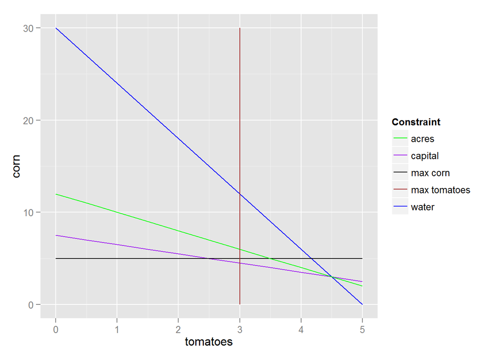

```r
f1 <- function(x) 30-6*x
f2 <- function(x) 7.5 - x
f3 <- function(x) 5
f4 <- function(x) 12-2*x
x1 = seq(0,5, by = .5)
x0 = rep(3,length(x1))
df = data.frame(x1,x0, water=f1(x1), capital=f2(x1),max_tomato= f3(x1), acres = f4(x1))
df <-  transform(df, z =pmax(pmin(water,capital,acres),5), z2 = pmax(x1,3))
ggplot(df, aes(x = x1)) +
  geom_line(aes(y = water, colour = 'water'))+
  geom_line(aes(y = capital, colour = 'capital'))+
  geom_line(aes(y = max_tomato, colour = 'max corn')) +
  geom_line(aes(y = acres, colour = 'acres')) +
  geom_line(aes(y = water, x = x0, colour = 'max tomatoes'))+
  geom_ribbon(aes(ymin=5, ymax = z, x= z2), fill = 'gray80') +
  scale_colour_manual(name = "Constraint", values=c("green", "purple","black","brown","blue"))+
  ylab("corn") + xlab("tomatoes")
```

The farmer would not be able to fulfill the contract and should not sign.

*Part C: Assume the farmer can obtain an additional 10,000 gallons of water for $50 per gallon. Should he obtain the additional water?*

The farmer should not obtain the additional water. The line representing the water (blue) does not constrain the available values. They are still constrained by the available capital, meaning additional water will not result in an increase for $n_{t}$ or $n_{c}$ because there is not enough capital available to support the needed labor.

Additionally, because additional water will cost additional capital, obtaining more water will in fact reduce the maximum profit from the original scenario.

The new scenario changes these constraints:

40,000 gallons of water available, $w \leq 40$

Each unit of $n_{t}$ needs 1k gallons water, and each unit $n_{c}$ needs 6k gallons  
$n_{t} + 6n_{c} \leq w \leq 40$ $n_{t} \leq 40 - 6n_{c}$  
$700 starting capital available. Labor is $100 per 100 bushels ($50 spend on water) $100(n_{t} + n_{c}) \leq 700$ $n_{t} \leq 7 - n_{c}$

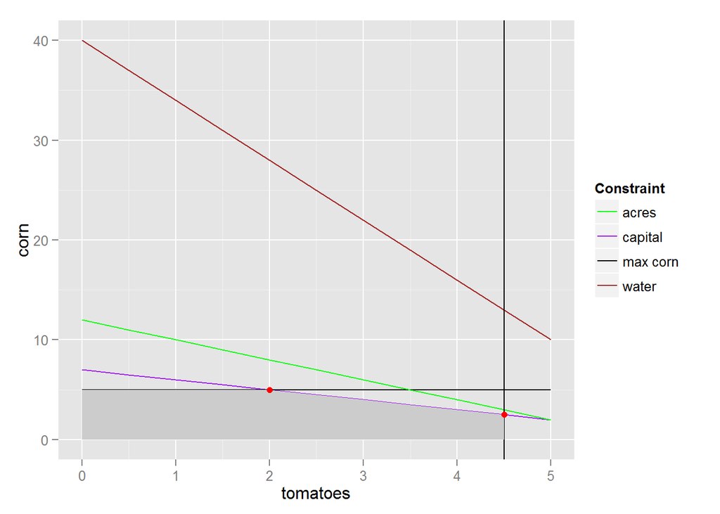

```r
f1 <- function(x) 40-6*x
f2 <- function(x) 7 - x
f3 <- function(x) 5
f4 <- function(x) 12-2*x
x1 = seq(0,5, by = .5)
x0 = rep(4.5,length(x1))
df = data.frame(x1,x0, water=f1(x1), capital=f2(x1),max_corn= f3(x1), acres = f4(x1))
df <-  transform(df, z =pmin(water,capital,5,acres), z2 = pmin(x1,4.5))
ggplot(df, aes(x = x1)) +
  geom_line(aes(y = water, colour = 'water'))+
  geom_line(aes(y = capital, colour = 'capital'))+
  geom_line(aes(y = max_corn, colour = 'max corn')) +
  geom_line(aes(y = acres, colour = 'acres')) +
  geom_vline(xintercept = 4.5, aes(colour = "max tomatoes")) +
  geom_ribbon(aes(ymin=0, ymax = z, x= z2), fill = 'gray80') +
  geom_point(aes(x = 4.5, y=f2(4.5)), color="red")+
  geom_point(aes(x = 2, y=f2(2)), color="red")+
  scale_colour_manual(name = "Constraint", values=c("green", "purple","black","brown","blue"))+
  ylab("corn") + xlab("tomatoes")
```

## Reducing the available starting capital moves the point of maximum profit to $(2, 5)$ or $1,900. Nothing is gained by adding additional water unless the available capital increases as well.

## Chapter 12.5, Project 1

$\frac{dx}{dt} = 3x - xy$ $\frac{dy}{dt} = xy - 2y$ $x_{0} = 1, y_{0}=2$

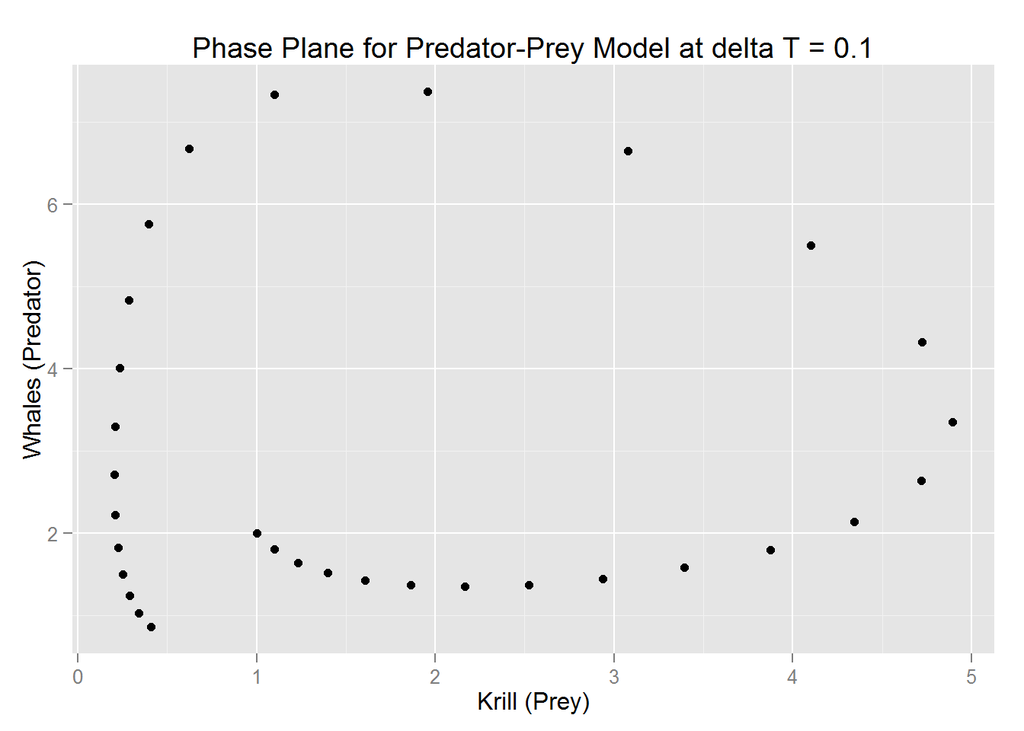

```r
x <- c(1)
y <- c(2)
deltaT <- 0.1
t <- seq(0,3,by=deltaT)

for (i in 1:30){
 x[i+1] <- x[i] + (3*x[i] - x[i]*y[i])*deltaT
 y[i+1] <- y[i] + (x[i]*y[i] - 2*y[i])*deltaT
}

df <- data.frame(t,x,y)

ggplot(df) +
  geom_point(aes(x=x,y=y)) +
  ggtitle("Phase Plane for Predator-Prey Model at delta T = 0.1") +
  xlab("Krill (Prey)") +
  ylab("Whales (Predator)")
```

[figure not shown]

```r
x2 <- c(1)
y2 <- c(2)
deltaT <- 0.001
t <- seq(0,3,by=deltaT)

for (i in 1:3000){
 x2[i+1] <- x2[i] + (3*x2[i] - x2[i]*y2[i])*deltaT
 y2[i+1] <- y2[i] + (x2[i]*y2[i] - 2*y2[i])*deltaT
}

df <- data.frame(t,x2,y2)

ggplot(df) +
  geom_point(aes(x=x2,y=y2)) +
  ggtitle("Phase Plane for Predator-Prey Model at delta T = 0.1") +
  xlab("Krill (Prey)") +
  ylab("Whales (Predator)")
```

Instead of reducing the value of $\Delta t$, we will see if we can improve the accuracy of the approximation using the improved Euler’s method, in which the solution trajectory is found by taking the average of the two slopes:

$x_{n+1} = x_{n} + \left[f(t_{n},x_{n},y_{n}) + f(t_{n+1},x_{n+1}^{*},y_{n+1}^{*})\right]\frac{\Delta t}{2}$ $y_{n+1} = y_{n} + \left[g(t_{n},x_{n},y_{n}) + g(t_{n+1},x_{n+1}^{*},y_{n+1}^{*})\right]\frac{\Delta t}{2}$

The values of $x_{n+1}^{*}$ and $y_{n+1}^{*}$ will be the estimates from the original Euler method above.

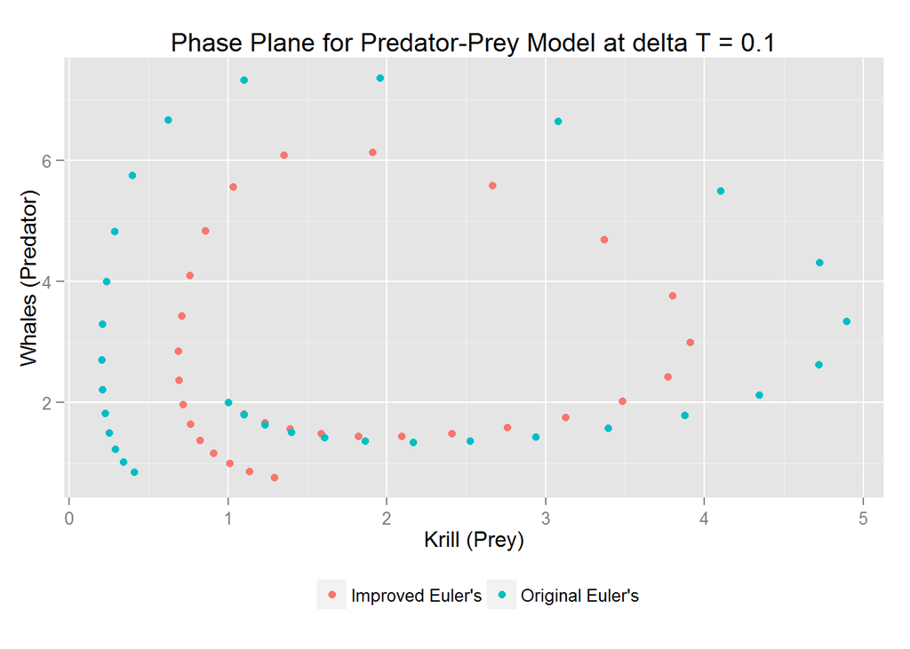

```r
xstar <- x
ystar <- y
x <- c(1) # re-initialize vectors
y <- c(2)
deltaT <- 0.1
t <- seq(0,3,by=deltaT)

for (i in 1:30){
 x[i+1] <- x[i] + (3*x[i] - x[i]*y[i] + 3*xstar[i] - xstar[i+1]*ystar[i+1])*deltaT/2
 y[i+1] <- y[i] + (x[i]*y[i] - 2*y[i] + xstar[i+1]*ystar[i+1] - 2*ystar[i+1])*deltaT/2
}

df <- data.frame(t,x,y,xstar,ystar)

ggplot(df) +
  geom_point(aes(x=x,y=y,color="Improved Euler's")) +
  geom_point(aes(x=xstar,y=ystar,color="Original Euler's")) +
  ggtitle("Phase Plane for Predator-Prey Model at delta T = 0.1") +
  xlab("Krill (Prey)") +
  ylab("Whales (Predator)") +
  theme(legend.title = element_blank(),legend.position="bottom")
```

In this plot, we can see how this method improves the accuracy of the approximation without having to reduce the value of $\Delta t$. The points in red show us that the solution trajectory for improved Euler’s is “tighter” than original Euler’s. Although the approximations do not cycle around exactly to the point $(1,2)$, the trajectory is demonstrably more periodic than the original method.